# R for beginners Notebook

## R Biostat. and data analysis

## R Biostat. basics

Useful functions:

- sum(x) –> Sums the elements in x
- prod(x) –> Product of the elements in x
- max(x) –> Maximum element in x
- min(x) –> Minimum element in x
- range(x) –> Range (min to max) of elements in x

## R Biostat. basics

Useful functions:

- mean(x) –> Mean (average value) of elements in x.
- median(x) –> Median (middle value) of elements in x
- var(x) –> Variance of elements in x
- sd(x) –> Standard deviation of element in x
- cor(x,y) –> Correlation between x and y
- cov(x,y) –> Covariance between x and y
- quantile(x,p) –> The pth quantile of x

## R Biostat. basics

Example: patients data

```r
set.seed(21341)
patients.df <- data.frame(
  "ID"=paste0("p",1:100)
  ,"Gender"=factor(sample(c("F","M"),100,replace = T))
  ,"Stage"=factor(sample(c("I","II","III","IV"),100,replace = T))
  ,"Age"=rgamma(100,shape = 50)
  ,"TumorVolume"=rgamma(100,shape = 10)
  ,stringsAsFactors = F)

head(patients.df)
```

```
##   ID Gender Stage      Age TumorVolume
## 1 p1      F    II 43.95789    9.255460
## 2 p2      F     I 56.74672   13.032624
## 3 p3      F    II 59.69381   15.205465
## 4 p4      M    IV 48.46508   10.720874
## 5 p5      F   III 57.92277    8.929090
## 6 p6      F    II 34.05087    8.440177
```

## R Biostat. basics

```r
quantile(patients.df$Age)
```

```
##       0%      25%      50%      75%     100%
## 33.29934 43.96218 49.18707 53.77041 77.28883
```

## R Biostat. basics

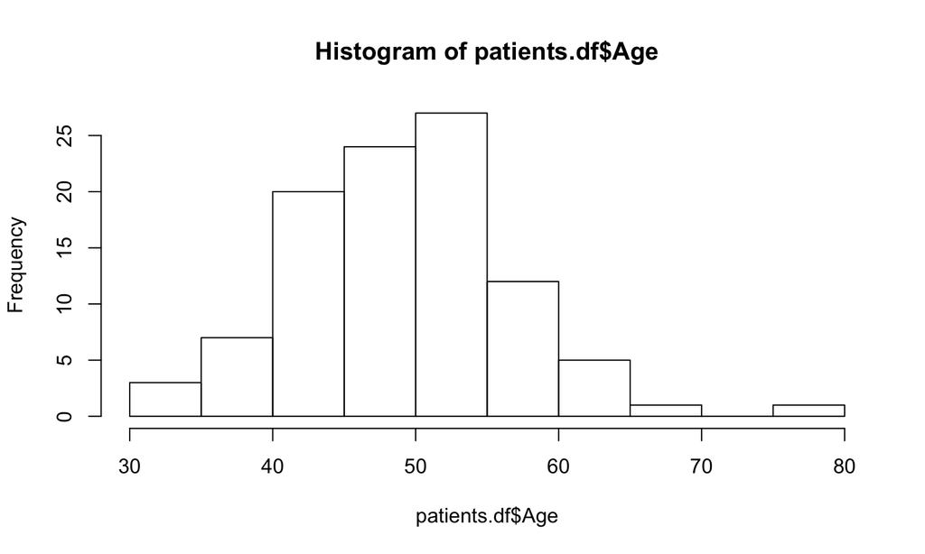

```r
hist(patients.df$Age)
```

## R Biostat. basics

```r
summary(patients.df$Stage)
```

```
##   I  II III  IV
##  29  28  22  21
```

```r
table(patients.df$Stage)
```

```
##
##   I  II III  IV
##  29  28  22  21
```

## R Biostat. basics

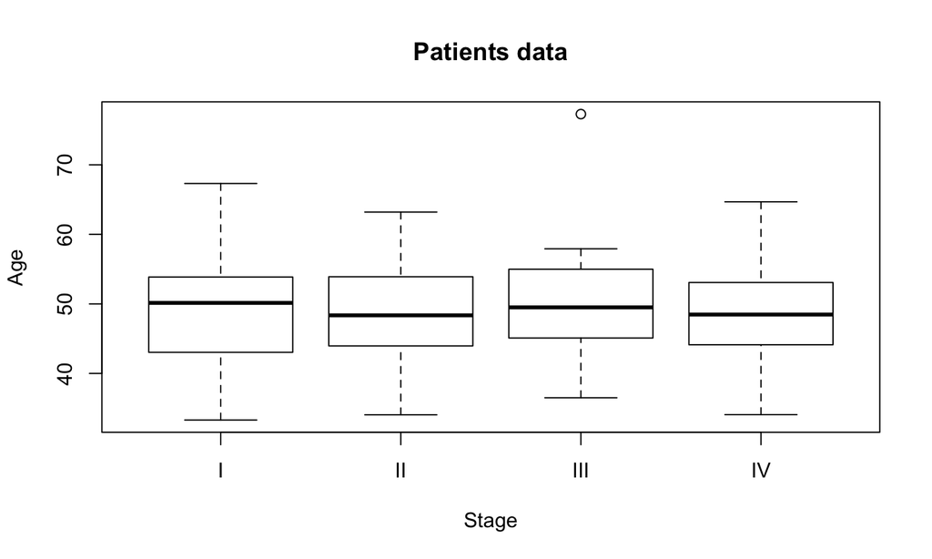

```r
boxplot(Age ~ Stage, patients.df
  , ylab="Age",xlab="Stage",main="Patients data")
```

## R Biostat. basics

T-test and Wilcoxcon rank sum test

- T-test measures the difference in mean between two independent populations [assumes normal distribution]
- Wilcoxcon rank sum test measures the difference in median between two independent populations [non-parametric]

## R Biostat. basics

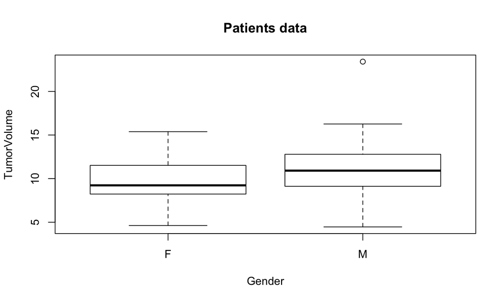

```r
boxplot(TumorVolume ~ Gender, patients.df
  , ylab="TumorVolume",xlab="Gender",main="Patients data")
```

## R Biostat. basics

```r
  wilcox.test(x = patients.df$TumorVolume[patients.df$Gender=="M"]
              ,y = patients.df$TumorVolume[patients.df$Gender=="F"]
              ,mu = 0,alternative = "two.sided",paired = F,T)
```

```
##
##  Wilcoxon rank sum test
##
## data:  patients.df$TumorVolume[patients.df$Gender == "M"] and patients.df$TumorVolume[patients.df$Gender == "F"]
## W = 1554, p-value = 0.03602
## alternative hypothesis: true location shift is not equal to 0
```

## R Biostat. basics

Let's check the correlation between Age and Tumor volume

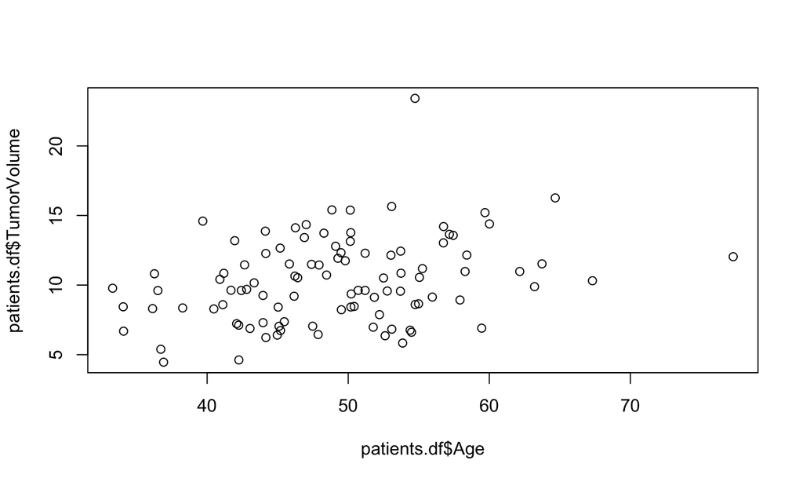

```r
plot(patients.df$Age,patients.df$TumorVolume)
```

## R Biostat. basics

- Pearson product moment correlation :The Pearson correlation evaluates the linear relationship between two continuous variables.
- Spearman rank-order correlation: The Spearman correlation evaluates the monotonic relationship between two continuous or ordinal variables.

## R Biostat. basics

Let's check the correlation between Age and Tumor volume

```r
cor.test(patients.df$Age,patients.df$TumorVolume)
```

```
##
##  Pearson's product-moment correlation
##
## data:  patients.df$Age and patients.df$TumorVolume
## t = 3.1745, df = 98, p-value = 0.002006
## alternative hypothesis: true correlation is not equal to 0
## 95 percent confidence interval:
##  0.1158858 0.4733797
## sample estimates:
##       cor
## 0.3053534
```